# Isle of Skye Vegetation Survey — Birks (1973)

# 7 · Community Matrix & Clustering

Binary presence/absence matrix (species in ≥ 3 releves only), clustered with Ward’s D2 on Jaccard dissimilarities.

```r
# Build wide presence/absence matrix: rows = releves, cols = species
comm_long <- survey %>%
  filter(presence_binary == TRUE, !is.na(geo_releve_id)) %>%
  distinct(geo_releve_id, species)

# Keep only species found in 3 or more releves
keep_spp <- comm_long %>%
  count(species) %>%
  filter(n >= 3) %>%
  pull(species)

comm_wide <- comm_long %>%
  filter(species %in% keep_spp) %>%
  mutate(present = 1L) %>%
  pivot_wider(names_from  = species,
              values_from = present,
              values_fill = 0L) %>%
  column_to_rownames("geo_releve_id")

tibble(
  Metric  = c("Releves (rows)", "Species retained (cols)",
              "Species excluded (< 3 releves)", "Matrix fill %"),
  Value   = c(
    nrow(comm_wide),
    ncol(comm_wide),
    n_distinct(comm_long$species) - length(keep_spp),
    round(100 * sum(comm_wide) / prod(dim(comm_wide)), 1)
  )
) %>%
  kable(caption = "Table 6. Community matrix dimensions.") %>%
  kable_styling(bootstrap_options = c("striped","condensed"), full_width = FALSE)
```

Table 6. Community matrix dimensions.

| Metric | Value |
| --- | --- |
| Releves (rows) | 520.0 |
| Species retained (cols) | 559.0 |
| Species excluded (< 3 releves) | 300.0 |
| Matrix fill % | 2.7 |

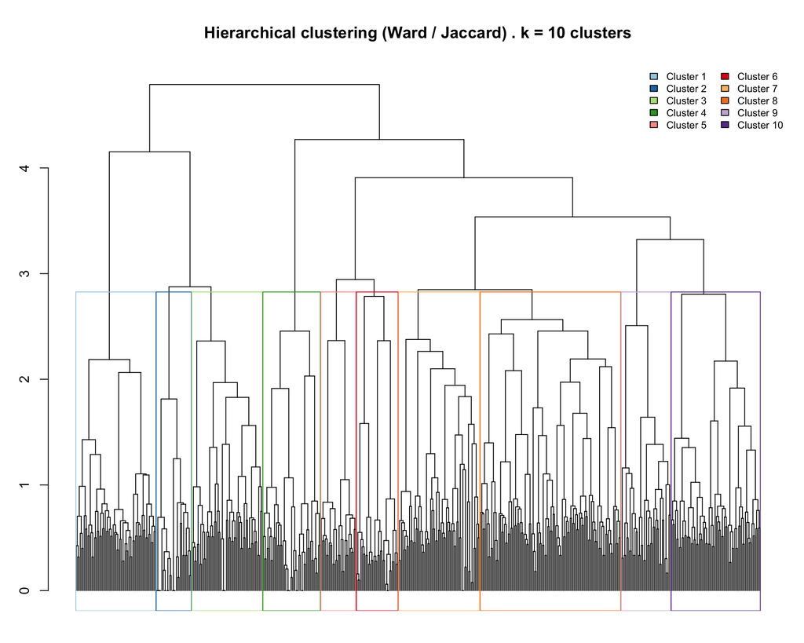

```r
set.seed(42)
jac_dist <- vegdist(comm_wide, method = "jaccard", binary = TRUE)
hc        <- hclust(jac_dist, method = "ward.D2")
K         <- 10
clusters  <- cutree(hc, k = K)
cluster_cols <- setNames(
  colorRampPalette(brewer.pal(10, "Paired"))(K),
  as.character(1:K)
)

par(mar = c(2, 3, 4, 1))
plot(as.dendrogram(hc), leaflab = "none",
     main = glue("Hierarchical clustering (Ward / Jaccard) . k = {K} clusters"),
     ylab = "Height (Jaccard dissimilarity)")
rect.hclust(hc, k = K, border = cluster_cols)
legend("topright", legend = paste("Cluster", 1:K),
       fill = cluster_cols, cex = 0.75, ncol = 2, bty = "n")
```

```r
cluster_df <- tibble(
  geo_releve_id = as.integer(names(clusters)),
  cluster       = clusters
)

# Also create sp_mat alias so section 9 works
sp_mat <- comm_wide

survey %>%
  distinct(geo_releve_id, association, class) %>%
  inner_join(cluster_df, by = "geo_releve_id") %>%
  filter(!is.na(association)) %>%
  count(Class = class, Association = association, cluster) %>%
  pivot_wider(names_from = cluster, values_from = n,
              values_fill = 0L, names_prefix = "C") %>%
  arrange(Class, Association) %>%
  datatable(
    caption = glue("Table 7. Releve count per association x cluster (k = {K})."),
    options = list(pageLength = 20),
    class   = "stripe hover compact"
  )
```

|  | Class | Association | C4 | C3 | C2 | C9 | C8 | C1 | C5 | C6 | C7 | C10 |
| --- | --- | --- | --- | --- | --- | --- | --- | --- | --- | --- | --- | --- |
| 1 | ALNETEA GLUTINOSAE | Alnus glutinosa woods | 1 | 0 | 0 | 0 | 0 | 0 | 0 | 0 | 0 | 0 |
| 2 | ALNETEA GLUTINOSAE | Epiphytic bryophytes and lichens in Alnus glutinosa woods | 3 | 0 | 0 | 0 | 0 | 0 | 0 | 0 | 0 | 0 |
| 3 | AMMOPHILETEA | Fore-dune communities | 2 | 0 | 0 | 0 | 0 | 0 | 0 | 0 | 0 | 0 |
| 4 | AMMOPHILETEA | Grey dune Turfs | 2 | 0 | 0 | 0 | 0 | 0 | 0 | 0 | 0 | 0 |
| 5 | ASPLENIETEA RUPESTRIS | Asplenium marinum-Grimmia maritima | 0 | 8 | 0 | 0 | 0 | 0 | 0 | 0 | 0 | 0 |
| 6 | ASPLENIETEA RUPESTRIS | Asplenium trichomanes-Fissidens cristatus | 0 | 0 | 14 | 0 | 0 | 0 | 0 | 0 | 0 | 0 |
| 7 | ASTERETEA TRIPOLIUM | Armeria maritima-Grimmia maritima | 0 | 9 | 0 | 0 | 0 | 0 | 0 | 0 | 0 | 0 |
| 8 | ASTERETEA TRIPOLIUM | Juncus gerardii-Carex extensa | 2 | 15 | 0 | 0 | 0 | 0 | 0 | 0 | 0 | 0 |
| 9 | ASTERETEA TRIPOLIUM | Puccinellietum maritimae (Puccinellia-Asplenium nodosum subass.) | 0 | 6 | 0 | 0 | 0 | 0 | 0 | 0 | 0 | 0 |
| 10 | ASTERETEA TRIPOLIUM | Puccinellietum maritimae (Puccinellia-Festuca rubra subass.) | 0 | 6 | 0 | 0 | 0 | 0 | 0 | 0 | 0 | 0 |

[output cut: 57 more lines]

# 7 · Cluster Ecological Profiles

## 7.1 · Are the Clusters Statistically Meaningful?

```r
set.seed(42)
cluster_fac   <- factor(clusters[rownames(sp_mat)])
permanova_res <- adonis2(jac_dist ~ cluster_fac, permutations = 199)

tibble(
  Term      = c("Cluster membership", "Residual", "Total"),
  Df        = permanova_res$Df,
  `Sum Sq`  = round(permanova_res$SumOfSqs, 2),
  R2        = round(permanova_res$R2, 3),
  F         = round(permanova_res$F, 2),
  `p-value` = permanova_res$`Pr(>F)`
) %>%
  kable(caption = glue("Table 7a. PERMANOVA (199 permutations, k = {K})."),
        digits = 3, na.rm = TRUE) %>%
  kable_styling(bootstrap_options = c("striped","hover"), full_width = FALSE)
```

Table 7a. PERMANOVA (199 permutations, k = 10).

| Term | Df | Sum Sq | R2 | F | p-value |
| --- | --- | --- | --- | --- | --- |
| Cluster membership | 9 | 61.13 | 0.25 | 18.92 | 0.005 |
| Residual | 510 | 183.11 | 0.75 | NA | NA |
| Total | 519 | 244.24 | 1.00 | NA | NA |

```r
have_indic <- requireNamespace("indicspecies", quietly = TRUE)
if (have_indic) {
  set.seed(42)
  indic_res <- indicspecies::multipatt(
    sp_mat, cluster_fac, func = "r.g", duleg = TRUE,
    control = permute::how(nperm = 199)
  )
  indic_tbl <- indic_res$sign %>%
    as_tibble(rownames = "species") %>%
    filter(p.value <= 0.05, !is.na(p.value)) %>%
    mutate(cluster = as.integer(index)) %>%
    select(cluster, species, stat, p.value) %>%
    arrange(cluster, desc(stat))
} else {
  indic_tbl <- tibble(cluster = integer(), species = character(),
                       stat = double(), p.value = double())
}
```

```r
if (nrow(indic_tbl) > 0) {
  indic_tbl %>%
    group_by(cluster) %>%
    slice_max(stat, n = 5, with_ties = FALSE) %>%
    ungroup() %>%
    rename(Cluster = cluster, Species = species,
           `Indicator value` = stat, `p-value` = p.value) %>%
    mutate(`Indicator value` = round(`Indicator value`, 3),
           `p-value` = round(`p-value`, 3)) %>%
    datatable(
      caption = "Table 7b. Statistically significant indicator species per cluster (p <= 0.05, top 5 per cluster).",
      filter  = "top",
      options = list(pageLength = 15),
      class   = "stripe hover compact"
    )
} else {
  cat("No indicator species reached p <= 0.05.")
}
```

|  | Cluster | Species | Indicator value | p-value |
| --- | --- | --- | --- | --- |
| 1 | 1 | Dicranum scoparium | 0.708 | 0.005 |
| 2 | 1 | H. cupressiforme var. resupinatum | 0.617 | 0.005 |
| 3 | 1 | Ulota bruchii | 0.617 | 0.005 |
| 4 | 1 | U. crispa | 0.617 | 0.005 |
| 5 | 1 | F. tamarisci | 0.617 | 0.005 |
| 6 | 2 | Deschampsia cespitosa | 0.517 | 0.005 |
| 7 | 2 | Betula pubescens ssp. odorata | 0.435 | 0.005 |
| 8 | 2 | Viola riviniana | 0.418 | 0.005 |
| 9 | 2 | Ranunculus acris | 0.41 | 0.005 |
| 10 | 2 | A. trichomanes | 0.403 | 0.005 |

[output cut: 40 more lines]

## 7.2 · Diversity and Spread by Cluster

```r
div_df <- tibble(
  geo_releve_id = as.integer(rownames(sp_mat)),
  richness      = specnumber(sp_mat),
  shannon       = diversity(sp_mat, index = "shannon"),
  simpson       = diversity(sp_mat, index = "simpson")
) %>%
  mutate(evenness = if_else(richness > 1, shannon / log(richness), NA_real_)) %>%
  left_join(cluster_df, by = "geo_releve_id") %>%
  left_join(survey %>% distinct(geo_releve_id, class, association),
            by = "geo_releve_id")

cluster_summary <- div_df %>%
  group_by(cluster) %>%
  summarise(
    n_releves      = n(),
    mean_richness  = round(mean(richness), 1),
    sd_richness    = round(sd(richness), 1),
    mean_shannon   = round(mean(shannon), 2),
    mean_simpson   = round(mean(simpson), 2),
    mean_evenness  = round(mean(evenness, na.rm = TRUE), 2),
    dominant_class = names(sort(table(class), decreasing = TRUE))[1],
    dominant_assoc = names(sort(table(association), decreasing = TRUE))[1],
    .groups = "drop"
  ) %>%
  arrange(desc(n_releves))
```

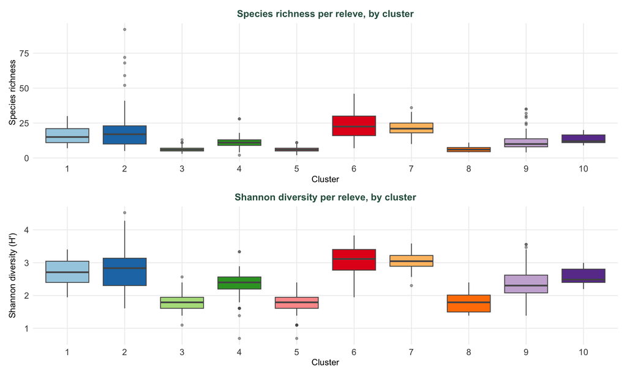

```r
p_div_box <- ggplot(div_df, aes(x = factor(cluster), y = richness,
                                 fill = factor(cluster))) +
  geom_boxplot(show.legend = FALSE, outlier.size = 1, outlier.alpha = 0.5,
               colour = "#555555") +
  scale_fill_manual(values = cluster_cols) +
  labs(title = "Species richness per releve, by cluster",
       x = "Cluster", y = "Species richness") +
  theme_skye(10)

p_div_shannon <- ggplot(div_df, aes(x = factor(cluster), y = shannon,
                                      fill = factor(cluster))) +
  geom_boxplot(show.legend = FALSE, outlier.size = 1, outlier.alpha = 0.5,
               colour = "#555555") +
  scale_fill_manual(values = cluster_cols) +
  labs(title = "Shannon diversity per releve, by cluster",
       x = "Cluster", y = "Shannon diversity (H')") +
  theme_skye(10)

p_div_box / p_div_shannon
```

### Per-Cluster Summary Table

```r
cluster_summary %>%
  rename(Cluster = cluster, `Releves (n)` = n_releves,
         `Mean richness` = mean_richness, `SD richness` = sd_richness,
         `Mean Shannon` = mean_shannon, `Mean Simpson` = mean_simpson,
         `Mean evenness` = mean_evenness,
         `Dominant class` = dominant_class,
         `Dominant association` = dominant_assoc) %>%
  datatable(
    caption = "Table 7c. Diversity, spread, and dominant vegetation unit per cluster.",
    options = list(pageLength = 10, dom = "t"),
    class   = "stripe hover compact"
  )
```

|  | Cluster | Releves (n) | Mean richness | SD richness | Mean Shannon | Mean Simpson | Mean evenness | Dominant class | Dominant association |
| --- | --- | --- | --- | --- | --- | --- | --- | --- | --- |
| 1 | 2 | 107 | 19.7 | 14.3 | 2.79 | 0.93 | 1 | MONTIO-CARDAMINETEA | Asplenium trichomanes-Fissidens cristatus |
| 2 | 6 | 68 | 23.5 | 8.7 | 3.08 | 0.95 | 1 | SCHEUCHZERIO-CARICETEA FUSCAE | Eriophorum latifolium-Carex hostiana |
| 3 | 4 | 63 | 11.2 | 4.7 | 2.32 | 0.89 | 1 | MOLINIO-ARRHENATHERETEA | Centaureo-Cynosuretum |
| 4 | 7 | 61 | 21.6 | 5.2 | 3.04 | 0.95 | 1 | OXYCOCCO-SPHAGNETEA | Trichophoreto-Eriophoretum |
| 5 | 9 | 54 | 12.6 | 7.7 | 2.39 | 0.9 | 1 | NARDO-CALLUNETEA | Nardus stricta-Vaccinium myrtillus |
| 6 | 3 | 44 | 6.4 | 2 | 1.82 | 0.83 | 1 | ASTERETEA TRIPOLIUM | Juncus gerardii-Carex extensa |
| 7 | 5 | 38 | 5.8 | 2.2 | 1.69 | 0.8 | 1 | PHRAGMITETEA | Littorella uniflora-Lobelia dortmanna |
| 8 | 1 | 32 | 16.6 | 6.2 | 2.74 | 0.93 | 1 | EPIPETRETEA LICHENOSA | Epiphytic bryophytes and lichens in the Betula-Vaccinium myrtillus and Corylus-Oxalis acetosella Associations |
| 9 | 8 | 27 | 6.4 | 2.1 | 1.8 | 0.83 | 1 | CARICETEA CURVULAE | Rhacomitreto-Callunettum |
| 10 | 10 | 27 | 13.7 | 3.5 | 2.59 | 0.92 | 1 | QUERCETEA ROBORI-PETRAEAE | Oxalis acetosella-Rhytidiadelphus loreus |

### Narrative Summary - Top 3 Clusters by Size

```r
top3_clusters <- cluster_summary %>% slice_head(n = 3) %>% pull(cluster)

for (cl in top3_clusters) {
  cl_row <- cluster_summary %>% filter(cluster == cl)
  top_sp <- div_df %>%
    filter(cluster == cl) %>%
    pull(geo_releve_id) %>%
    as.character() %>%
    { sp_mat[., , drop = FALSE] } %>%
    colSums() %>%
    sort(decreasing = TRUE) %>%
    head(5)
  top_sp_str <- paste(glue("*{names(top_sp)}* ({round(100 * top_sp / cl_row$n_releves, 0)}%)"),
                      collapse = ", ")
  indic_str <- indic_tbl %>%
    filter(cluster == cl) %>%
    slice_max(stat, n = 3, with_ties = FALSE) %>%
    pull(species)
  indic_str <- if (length(indic_str) > 0) paste(glue("*{indic_str}*"), collapse = ", ") else "none reached p <= 0.05"

  cat(glue(
    "\n\n**Cluster {cl}** ({cl_row$n_releves} releves, dominated by *{cl_row$dominant_class}* -- mostly the *{cl_row$dominant_assoc}* association): ",
    "mean species richness {cl_row$mean_richness} (Shannon H' = {cl_row$mean_shannon}). ",
    "Most frequent species: {top_sp_str}. ",
    "Statistically significant indicator species: {indic_str}.\n"
  ))
}
```

**Cluster 2** (107 releves, dominated by *MONTIO-CARDAMINETEA* – mostly the *Asplenium trichomanes-Fissidens cristatus* association): mean species richness 19.7 (Shannon H’ = 2.79). Most frequent species: *Deschampsia cespitosa* (36%), *Festuca ovina* (29%), *Thymus drucei* (25%), *Viola riviniana* (25%), *Ranunculus acris* (25%). Statistically significant indicator species: *Deschampsia cespitosa*, *Betula pubescens ssp. odorata*, *Viola riviniana*. **Cluster 6** (68 releves, dominated by *SCHEUCHZERIO-CARICETEA FUSCAE* – mostly the *Eriophorum latifolium-Carex hostiana* association): mean species richness 23.5 (Shannon H’ = 3.08). Most frequent species: *C. nigra* (59%), *C. panicea* (57%), *Campylium stellatum* (56%), *Scorpidium scorpioides* (51%), *Eriophorum angustifolium* (50%). Statistically significant indicator species: *Campylium stellatum*, *Scorpidium scorpioides*, *C. nigra*. **Cluster 4** (63 releves, dominated by *MOLINIO-ARRHENATHERETEA* – mostly the *Centaureo-Cynosuretum* association): mean species richness 11.2 (Shannon H’ = 2.32). Most frequent species: *Plantago lanceolata* (49%), *Agrostis stolonifera* (30%), *Festuca rubra* (29%), *Ranunculus repens* (29%), *Cynosurus cristatus* (25%). Statistically significant indicator species: *Plantago lanceolata*, *Centaurea nigra*, *Trifolium pratense*.

## 7.3 · What Dominates Each Cluster

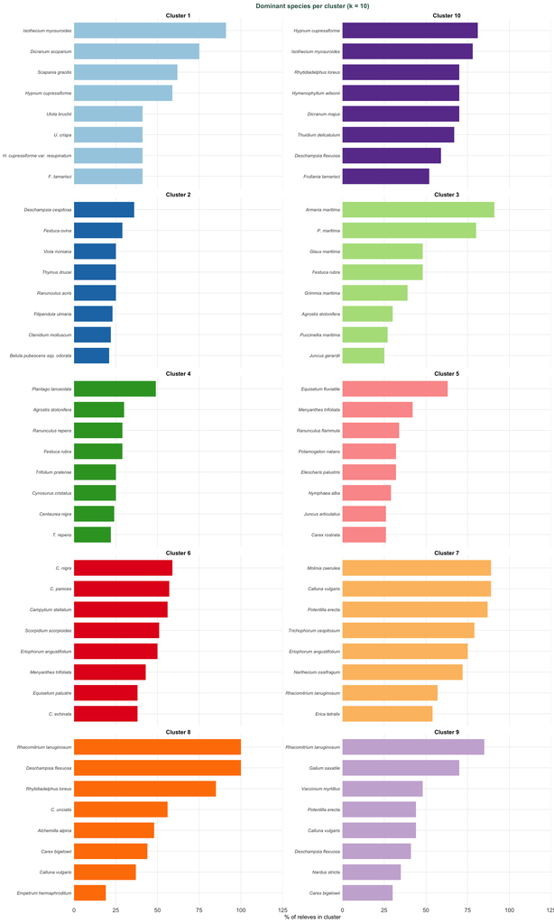

```r
cluster_top_sp <- div_df %>%
  select(geo_releve_id, cluster) %>%
  left_join(
    survey %>% filter(presence_binary == TRUE) %>%
      select(geo_releve_id, species),
    by = "geo_releve_id"
  ) %>%
  count(cluster, species, name = "n") %>%
  left_join(cluster_summary %>% select(cluster, n_releves), by = "cluster") %>%
  mutate(pct = round(100 * n / n_releves, 0)) %>%
  group_by(cluster) %>%
  slice_max(pct, n = 8, with_ties = FALSE) %>%
  ungroup() %>%
  mutate(sp_label = paste(cluster, species, sep = "___"),
         sp_label = fct_reorder(sp_label, pct))

ggplot(cluster_top_sp,
       aes(x = pct, y = sp_label, fill = factor(cluster))) +
  geom_col(width = 0.75, show.legend = FALSE) +
  scale_fill_manual(values = cluster_cols) +
  scale_y_discrete(labels = function(x) str_remove(x, ".*___")) +
  scale_x_continuous(expand = expansion(mult = c(0, 0.25))) +
  facet_wrap(~ glue("Cluster {cluster}"), scales = "free_y", ncol = 2) +
  labs(title = glue("Dominant species per cluster (k = {K})"),
       x = "% of releves in cluster", y = NULL) +
  theme_skye(9) +
  theme(strip.text  = element_text(size = 9, face = "bold"),
        axis.text.y = element_text(size = 7, face = "italic"))
```

## 7.4 · Cluster Composition - Stacked Proportions

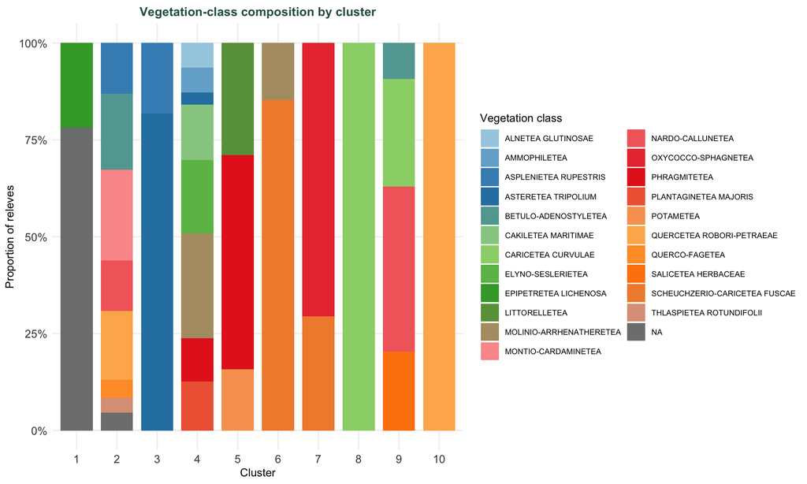

```r
stacked_class_df <- div_df %>%
  count(cluster, class, name = "n") %>%
  group_by(cluster) %>%
  mutate(prop = n / sum(n)) %>%
  ungroup()

class_pal_local <- colorRampPalette(brewer.pal(9, "Paired"))(n_distinct(stacked_class_df$class))

ggplot(stacked_class_df,
       aes(x = factor(cluster), y = prop, fill = class)) +
  geom_col(position = "fill", width = 0.8) +
  scale_fill_manual(values = class_pal_local, name = "Vegetation class") +
  scale_y_continuous(labels = scales::percent) +
  labs(title = "Vegetation-class composition by cluster",
       x = "Cluster", y = "Proportion of releves") +
  theme_skye(10) +
  theme(legend.text = element_text(size = 7), legend.position = "right")
```

# 10 · Releve Reference Table

Full geographic index of all releves.. Filter, search, or sort any column.

```r
survey %>%
  distinct(geo_releve_id, ref_code, table_id, latitude, longitude,
           altitude_m, slope_deg, aspect_deg, class, association) %>%
  arrange(geo_releve_id) %>%
  datatable(
    caption = "Table 8. Complete releve index, SW to NE.",
    filter  = "top",
    options = list(pageLength = 25, scrollX = TRUE),
    class   = "stripe hover compact"
  )
```

|  | geo_releve_id | ref_code | table_id | latitude | longitude | altitude_m | slope_deg | aspect_deg | class | association |
| --- | --- | --- | --- | --- | --- | --- | --- | --- | --- | --- |
| 1 | 1 | B68-013 | table_4_20 | 57.033278 | -6.003259 |  |  | 270 | SCHEUCHZERIO-CARICETEA FUSCAE | Molinia caerulea-Myrica gale |
| 2 | 2 | B68-012 | table_4_25 | 57.034065 | -5.978605 |  | 10 | 135 | SCHEUCHZERIO-CARICETEA FUSCAE | Eriophorum latifolium-Carex hostiana |
| 3 | 3 | B68-014 | table_4_13 | 57.037759 | -6.003741 |  |  |  | PHRAGMITETEA | Schoenoplectus lacustris-Phragmites communis (Schoenoplectus-Equisetum fluviatile subass.) |
| 4 | 4 | B68-328 | table_4_37 | 57.037969 | -5.997166 |  | 5 | 225 | CARICETEA CURVULAE | Rhacomitreto-Callunettum |
| 5 | 5 | B68-015 | table_4_13 | 57.043241 | -6.001032 |  |  |  | PHRAGMITETEA | Schoenoplectus lacustris-Phragmites communis (Phragmites-Equisetum fluviatile subass.) |
| 6 | 6 | B68-017 | table_4_13 | 57.043241 | -6.001032 |  |  |  | PHRAGMITETEA | Schoenoplectus lacustris-Phragmites communis (Phragmites-Equisetum fluviatile subass.) |
| 7 | 7 | B68-016 | table_4_18 | 57.043241 | -6.001032 |  |  |  | SCHEUCHZERIO-CARICETEA FUSCAE | Carex lasiocarpa-Menyanthes trifoliata |
| 8 | 8 | B67-104 | table_4_47 | 57.097631 | -5.95899 |  | 20 | 45 | BETULO-ADENOSTYLETEA | Betula pubescens-Cirsium heterophyllum / Sedum rosea-Alchemilla glabra |
| 9 | 9 | B67-106 | table_4_45 | 57.098527 | -5.959085 |  | 5 | 0 | BETULO-ADENOSTYLETEA | Luzula sylvatica-Vaccinium myrtillus |
| 10 | 10 | B67-105 | table_4_49 | 57.101216 | -5.959372 |  | 35 | 0 | QUERCETEA ROBORI-PETRAEAE | Betula pubescens-Vaccinium myrtillus / Corylus avellana-Oxalis acetosella |

[output cut: 511 more lines]

*Analysis by Bhagyesh Sagole & Pawan Kumar · Data: Birks H.J.B. (1973)*